# Chapter 5 - PCA and MCA

Seppo Nyrkkö *Fri Nov 27, 2020*

## i. reading the human equality data

```r
library(ggplot2)
library(GGally)
# read human data, row names in first column


human <- read.csv("data/human.csv",row.names=1)

# examine the structure

str(human)
```

```
## 'data.frame':    155 obs. of  8 variables:
##  $ ratiofm2edu : num  1.007 0.997 0.983 0.989 0.969 ...
##  $ ratiofmlabor: num  0.891 0.819 0.825 0.884 0.829 ...
##  $ eduexpy     : num  17.5 20.2 15.8 18.7 17.9 16.5 18.6 16.5 15.9 19.2 ...
##  $ lifeexp     : num  81.6 82.4 83 80.2 81.6 80.9 80.9 79.1 82 81.8 ...
##  $ gni         : int  64992 42261 56431 44025 45435 43919 39568 52947 42155 32689 ...
##  $ matmort     : int  4 6 6 5 6 7 9 28 11 8 ...
##  $ adolbirth   : num  7.8 12.1 1.9 5.1 6.2 3.8 8.2 31 14.5 25.3 ...
##  $ parlrepr    : num  39.6 30.5 28.5 38 36.9 36.9 19.9 19.4 28.2 31.4 ...
```

```r
dim(human)
```

```
## [1] 155   8
```

```r
summary(human)
```

```
##   ratiofm2edu      ratiofmlabor       eduexpy         lifeexp
##  Min.   :0.1717   Min.   :0.1857   Min.   : 5.40   Min.   :49.00
##  1st Qu.:0.7264   1st Qu.:0.5984   1st Qu.:11.25   1st Qu.:66.30
##  Median :0.9375   Median :0.7535   Median :13.50   Median :74.20
##  Mean   :0.8529   Mean   :0.7074   Mean   :13.18   Mean   :71.65
##  3rd Qu.:0.9968   3rd Qu.:0.8535   3rd Qu.:15.20   3rd Qu.:77.25
##  Max.   :1.4967   Max.   :1.0380   Max.   :20.20   Max.   :83.50
##       gni            matmort         adolbirth         parlrepr
##  Min.   :   581   Min.   :   1.0   Min.   :  0.60   Min.   : 0.00
##  1st Qu.:  4198   1st Qu.:  11.5   1st Qu.: 12.65   1st Qu.:12.40
##  Median : 12040   Median :  49.0   Median : 33.60   Median :19.30
##  Mean   : 17628   Mean   : 149.1   Mean   : 47.16   Mean   :20.91
##  3rd Qu.: 24512   3rd Qu.: 190.0   3rd Qu.: 71.95   3rd Qu.:27.95
##  Max.   :123124   Max.   :1100.0   Max.   :204.80   Max.   :57.50
```

The data has country as row name, ratio of 2nd education M/F, ratio of labor F/M, expected years of education, exp years of life, GNI of the nation, maternal mortality, adolescence birth rate and female parliament representation ratio.

Let’s see some ggpairs:

[figure not shown]

```r
ggpairs(human)
```

There might be some positive correlation between GNI and education years, and life years. Maternal mortality and adolescence birth has inverse correlation with GNI.

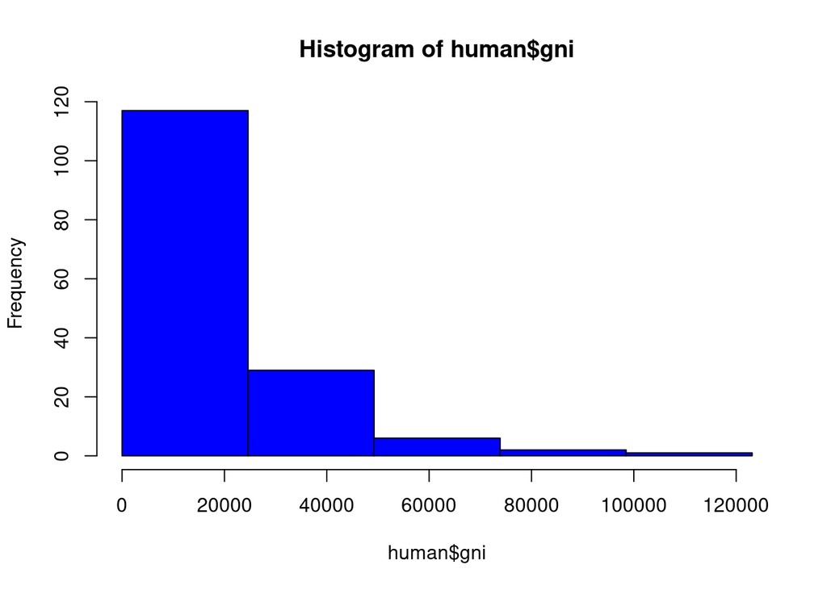

```r
hist(human$gni,breaks = seq(0,1,0.2)*max(human$gni),col='blue')
```

The highest GNI per capita rates are only in a few countries. Bear this in mind.

## ii. Some PCA

First, some PCA on the non-standardized data.

```r
pc_human <- prcomp(human)
pc_human
```

```
## Standard deviations (1, .., p=8):
## [1] 1.854416e+04 1.855219e+02 2.518701e+01 1.145441e+01 3.766241e+00
## [6] 1.565912e+00 1.912052e-01 1.591112e-01
##
## Rotation (n x k) = (8 x 8):
##                        PC1           PC2           PC3           PC4
## ratiofm2edu  -5.607472e-06  0.0006713951 -3.412027e-05 -2.736326e-04
## ratiofmlabor  2.331945e-07 -0.0002819357  5.302884e-04 -4.692578e-03
## eduexpy      -9.562910e-05  0.0075529759  1.427664e-02 -3.313505e-02
## lifeexp      -2.815823e-04  0.0283150248  1.294971e-02 -6.752684e-02
## gni          -9.999832e-01 -0.0057723054 -5.156742e-04  4.932889e-05
## matmort       5.655734e-03 -0.9916320120  1.260302e-01 -6.100534e-03
## adolbirth     1.233961e-03 -0.1255502723 -9.918113e-01  5.301595e-03
## parlrepr     -5.526460e-05  0.0032317269 -7.398331e-03 -9.971232e-01
##                        PC5           PC6           PC7           PC8
## ratiofm2edu  -0.0022935252  2.180183e-02  6.998623e-01  7.139410e-01
## ratiofmlabor  0.0022190154  3.264423e-02  7.132267e-01 -7.001533e-01
## eduexpy       0.1431180282  9.882477e-01 -3.826887e-02  7.776451e-03
## lifeexp       0.9865644425 -1.453515e-01  5.380452e-03  2.281723e-03
## gni          -0.0001135863 -2.711698e-05 -8.075191e-07 -1.176762e-06
## matmort       0.0266373214  1.695203e-03  1.355518e-04  8.371934e-04
## adolbirth     0.0188618600  1.273198e-02 -8.641234e-05 -1.707885e-04
## parlrepr     -0.0716401914 -2.309896e-02 -2.642548e-03  2.680113e-03
```

```r
summary(pc_human)
```

```
## Importance of components:
##                              PC1      PC2   PC3   PC4   PC5   PC6    PC7    PC8
## Standard deviation     1.854e+04 185.5219 25.19 11.45 3.766 1.566 0.1912 0.1591
## Proportion of Variance 9.999e-01   0.0001  0.00  0.00 0.000 0.000 0.0000 0.0000
## Cumulative Proportion  9.999e-01   1.0000  1.00  1.00 1.000 1.000 1.0000 1.0000
```

See the large differences in deviances.

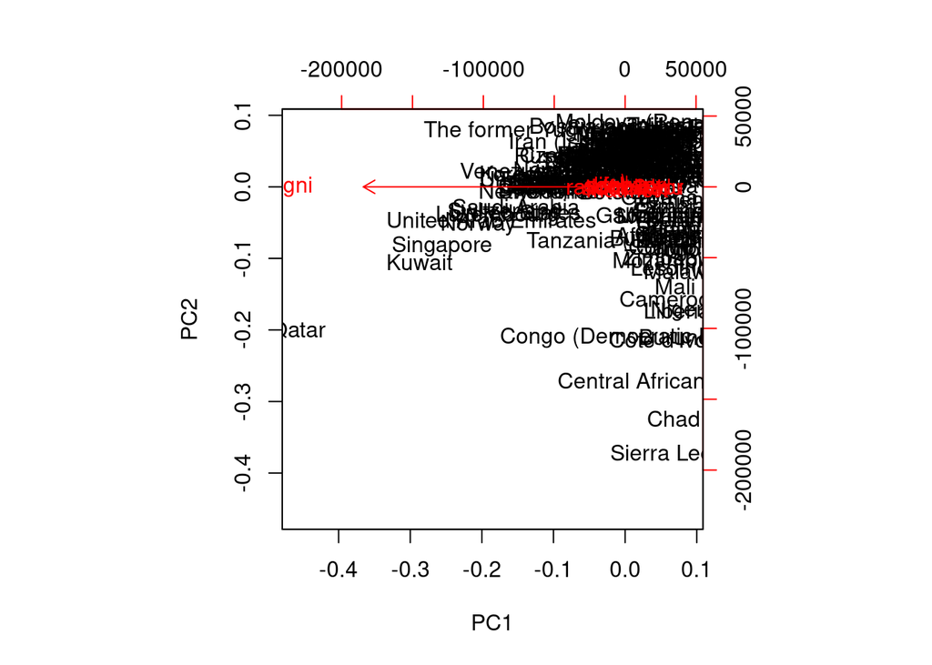

```r
biplot(pc_human)
```

This also gives a “not too clear” biplot. The data seems to be on a single axis: gni. (Might be caused from the fact that dollars and percentages are of different ranges)

## iii. PCA with standardized data

We’ll continue to standardizing the variables, and do the PCA again.

```r
stdpc_human <- prcomp(scale(human))
stdpc_human
```

```
## Standard deviations (1, .., p=8):
## [1] 2.0708380 1.1397204 0.8750485 0.7788630 0.6619563 0.5363061 0.4589994
## [8] 0.3222406
##
## Rotation (n x k) = (8 x 8):
##                      PC1         PC2         PC3         PC4        PC5
## ratiofm2edu  -0.35664370  0.03796058 -0.24223089  0.62678110 -0.5983585
## ratiofmlabor  0.05457785  0.72432726 -0.58428770  0.06199424  0.2625067
## eduexpy      -0.42766720  0.13940571 -0.07340270 -0.07020294  0.1659678
## lifeexp      -0.44372240 -0.02530473  0.10991305 -0.05834819  0.1628935
## gni          -0.35048295  0.05060876 -0.20168779 -0.72727675 -0.4950306
## matmort       0.43697098  0.14508727 -0.12522539 -0.25170614 -0.1800657
## adolbirth     0.41126010  0.07708468  0.01968243  0.04986763 -0.4672068
## parlrepr     -0.08438558  0.65136866  0.72506309  0.01396293 -0.1523699
##                      PC6         PC7         PC8
## ratiofm2edu   0.17713316  0.05773644  0.16459453
## ratiofmlabor -0.03500707 -0.22729927 -0.07304568
## eduexpy      -0.38606919  0.77962966 -0.05415984
## lifeexp      -0.42242796 -0.43406432  0.62737008
## gni           0.11120305 -0.13711838 -0.16961173
## matmort       0.17370039  0.35380306  0.72193946
## adolbirth    -0.76056557 -0.06897064 -0.14335186
## parlrepr      0.13749772  0.00568387 -0.02306476
```

Exploring some dimensions:

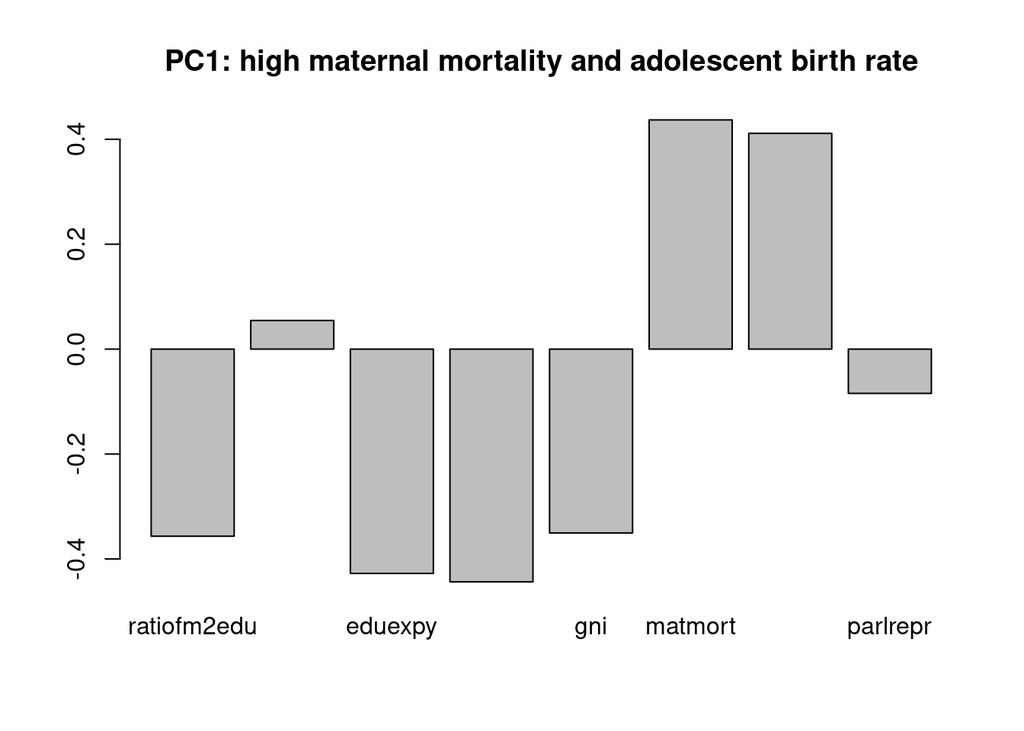

```r
barplot(stdpc_human$rotation[,1])
title('PC1: high maternal mortality and adolescent birth rate')
```

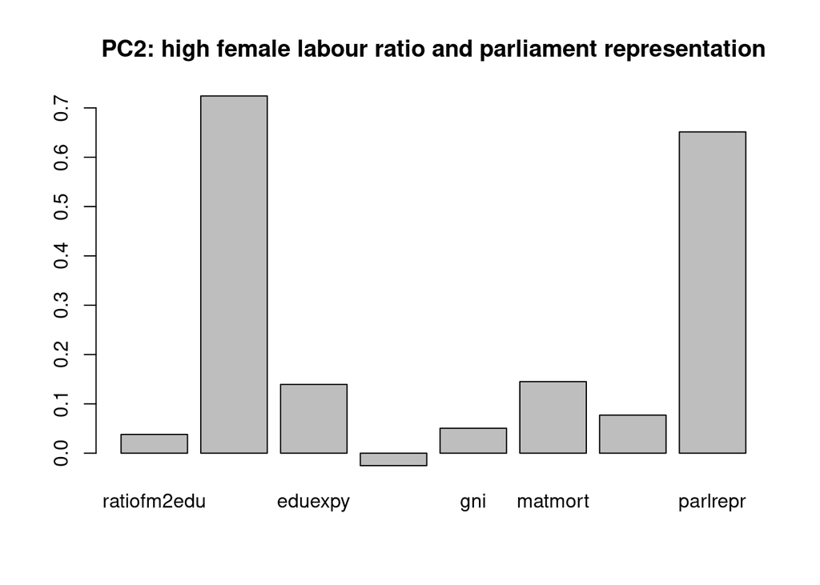

```r
barplot(stdpc_human$rotation[,2])
title('PC2: high female labour ratio and parliament representation')
```

```r
summary(stdpc_human)
```

```
## Importance of components:
##                           PC1    PC2     PC3     PC4     PC5     PC6     PC7
## Standard deviation     2.0708 1.1397 0.87505 0.77886 0.66196 0.53631 0.45900
## Proportion of Variance 0.5361 0.1624 0.09571 0.07583 0.05477 0.03595 0.02634
## Cumulative Proportion  0.5361 0.6984 0.79413 0.86996 0.92473 0.96069 0.98702
##                            PC8
## Standard deviation     0.32224
## Proportion of Variance 0.01298
## Cumulative Proportion  1.00000
```

## iv. Standardized human data biplot

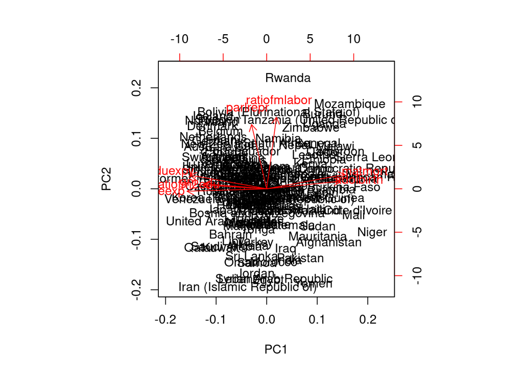

```r
biplot(stdpc_human)
```

Now the component arrows are distinguishable. Also the biplot is clerer to read as a “map”.

The PC1 component shows the dimension where GNI is low and maternal mortality and adolescent birth rate is high. The PC2 component shows a dimension where female labor is common but also parliament representation rate is higher.

## v. Tea dataset

```r
# some libraries
library(FactoMineR)
library(dplyr)
library(tidyr)
```

Let’s use the tea dataset which is a survey of tea consumption. 300 individuals answered, how they drink tea (18 Q), what are their product’s perception (12 Q) and some personal details (4 Q).

```r
data(tea)
str(tea)
```

```
## 'data.frame':    300 obs. of  36 variables:
##  $ breakfast       : Factor w/ 2 levels "breakfast","Not.breakfast": 1 1 2 2 1 2 1 2 1 1 ...
##  $ tea.time        : Factor w/ 2 levels "Not.tea time",..: 1 1 2 1 1 1 2 2 2 1 ...
##  $ evening         : Factor w/ 2 levels "evening","Not.evening": 2 2 1 2 1 2 2 1 2 1 ...
##  $ lunch           : Factor w/ 2 levels "lunch","Not.lunch": 2 2 2 2 2 2 2 2 2 2 ...
##  $ dinner          : Factor w/ 2 levels "dinner","Not.dinner": 2 2 1 1 2 1 2 2 2 2 ...
##  $ always          : Factor w/ 2 levels "always","Not.always": 2 2 2 2 1 2 2 2 2 2 ...
##  $ home            : Factor w/ 2 levels "home","Not.home": 1 1 1 1 1 1 1 1 1 1 ...
##  $ work            : Factor w/ 2 levels "Not.work","work": 1 1 2 1 1 1 1 1 1 1 ...
##  $ tearoom         : Factor w/ 2 levels "Not.tearoom",..: 1 1 1 1 1 1 1 1 1 2 ...
##  $ friends         : Factor w/ 2 levels "friends","Not.friends": 2 2 1 2 2 2 1 2 2 2 ...
##  $ resto           : Factor w/ 2 levels "Not.resto","resto": 1 1 2 1 1 1 1 1 1 1 ...
##  $ pub             : Factor w/ 2 levels "Not.pub","pub": 1 1 1 1 1 1 1 1 1 1 ...
##  $ Tea             : Factor w/ 3 levels "black","Earl Grey",..: 1 1 2 2 2 2 2 1 2 1 ...
##  $ How             : Factor w/ 4 levels "alone","lemon",..: 1 3 1 1 1 1 1 3 3 1 ...
```

[output cut: 22 more lines]

```r
# reduced dataset
tea_segments <- dplyr::select(tea, c("Tea", "relaxing", "effect.on.health", "sugar", "age_Q", "sex"))
str(tea_segments)
```

```
## 'data.frame':    300 obs. of  6 variables:
##  $ Tea             : Factor w/ 3 levels "black","Earl Grey",..: 1 1 2 2 2 2 2 1 2 1 ...
##  $ relaxing        : Factor w/ 2 levels "No.relaxing",..: 1 1 2 2 2 2 2 2 2 2 ...
##  $ effect.on.health: Factor w/ 2 levels "effect on health",..: 2 2 2 2 2 2 2 2 2 2 ...
##  $ sugar           : Factor w/ 2 levels "No.sugar","sugar": 2 1 1 2 1 1 1 1 1 1 ...
##  $ age_Q           : Factor w/ 5 levels "15-24","25-34",..: 3 4 4 1 4 1 3 3 3 3 ...
##  $ sex             : Factor w/ 2 levels "F","M": 2 1 1 2 2 2 2 1 2 2 ...
```

```r
dim(tea_segments)
```

```
## [1] 300   6
```

```r
summary(tea_segments)
```

```
##         Tea             relaxing              effect.on.health      sugar
##  black    : 74   No.relaxing:113   effect on health   : 66     No.sugar:155
##  Earl Grey:193   relaxing   :187   No.effect on health:234     sugar   :145
##  green    : 33
##
##
##    age_Q    sex
##  15-24:92   F:178
##  25-34:69   M:122
##  35-44:40
##  45-59:61
##  +60  :38
```

Now let’s do Multiple Correspondence Analysis on the reduced tea data

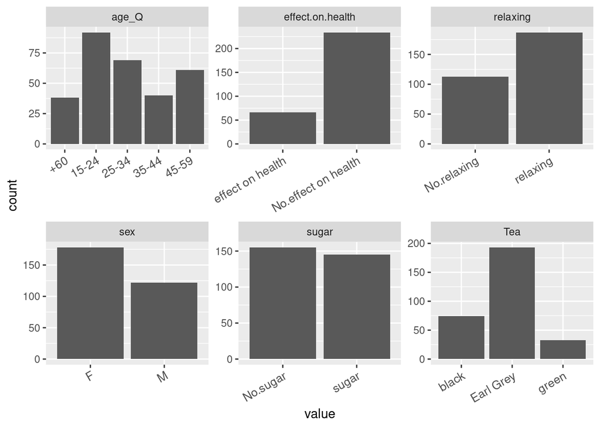

```r
# some visualization
gather(tea_segments) %>% ggplot(aes(value)) + facet_wrap("key", scales = "free") + geom_bar() + theme(axis.text.x = element_text(angle = 30, hjust = 1, size = 10))
```

We can see our factors are populated enough in all categories, in order to make some further analysis of our reduced data set.

Now continuing to the MCA (which is kind of categorial PCA):

```r
mca <- MCA(tea_segments, graph = FALSE)
# summary of the model
summary(mca)
```

```
##
## Call:
## MCA(X = tea_segments, graph = FALSE)
##
##
## Eigenvalues
##                        Dim.1   Dim.2   Dim.3   Dim.4   Dim.5   Dim.6   Dim.7
## Variance               0.271   0.228   0.207   0.182   0.172   0.151   0.134
## % of var.             16.232  13.667  12.445  10.919  10.329   9.038   8.038
## Cumulative % of var.  16.232  29.899  42.344  53.263  63.592  72.630  80.667
##                        Dim.8   Dim.9  Dim.10
## Variance               0.128   0.100   0.094
## % of var.              7.658   6.015   5.659
## Cumulative % of var.  88.326  94.341 100.000
##
## Individuals (the 10 first)
##                        Dim.1    ctr   cos2    Dim.2    ctr   cos2    Dim.3
## 1                   |  0.266  0.087  0.030 |  0.441  0.285  0.083 |  0.533
## 2                   |  1.002  1.237  0.572 | -0.333  0.163  0.063 | -0.224
## 3                   |  0.311  0.119  0.083 | -0.564  0.465  0.273 | -0.331
## 4                   | -0.817  0.822  0.643 |  0.023  0.001  0.001 |  0.122
## 5                   |  0.237  0.069  0.044 | -0.018  0.000  0.000 | -0.227
## 6                   | -0.380  0.178  0.142 | -0.187  0.051  0.034 |  0.098
## 7                   |  0.012  0.000  0.000 |  0.001  0.000  0.000 |  0.402
## 8                   |  0.494  0.300  0.121 | -0.436  0.278  0.094 |  0.830
## 9                   |  0.012  0.000  0.000 |  0.001  0.000  0.000 |  0.402
## 10                  |  0.420  0.217  0.082 |  0.110  0.018  0.006 |  0.935
##                        ctr   cos2
## 1                    0.457  0.122 |
## 2                    0.081  0.029 |
## 3                    0.176  0.094 |
## 4                    0.024  0.014 |
## 5                    0.083  0.040 |
## 6                    0.016  0.010 |
## 7                    0.259  0.094 |
## 8                    1.107  0.343 |
## 9                    0.259  0.094 |
## 10                   1.404  0.408 |
##
## Categories (the 10 first)
```

[output cut: 16 more lines]

```
## relaxing             -2.913 |   0.438   9.621   0.318   9.749 |
## effect on health      3.829 |  -0.110   0.212   0.003  -1.006 |
## No.effect on health  -3.829 |   0.031   0.060   0.003   1.006 |
## No.sugar             -5.200 |  -0.032   0.042   0.001  -0.571 |
## sugar                 5.200 |   0.034   0.045   0.001   0.571 |
## 15-24                -8.450 |  -0.008   0.002   0.000  -0.096 |
##
## Categorical variables (eta2)
##                       Dim.1 Dim.2 Dim.3
## Tea                 | 0.357 0.099 0.422 |
## relaxing            | 0.183 0.028 0.318 |
## effect.on.health    | 0.010 0.049 0.003 |
## sugar               | 0.464 0.090 0.001 |
## age_Q               | 0.596 0.511 0.480 |
## sex                 | 0.013 0.589 0.020 |
```

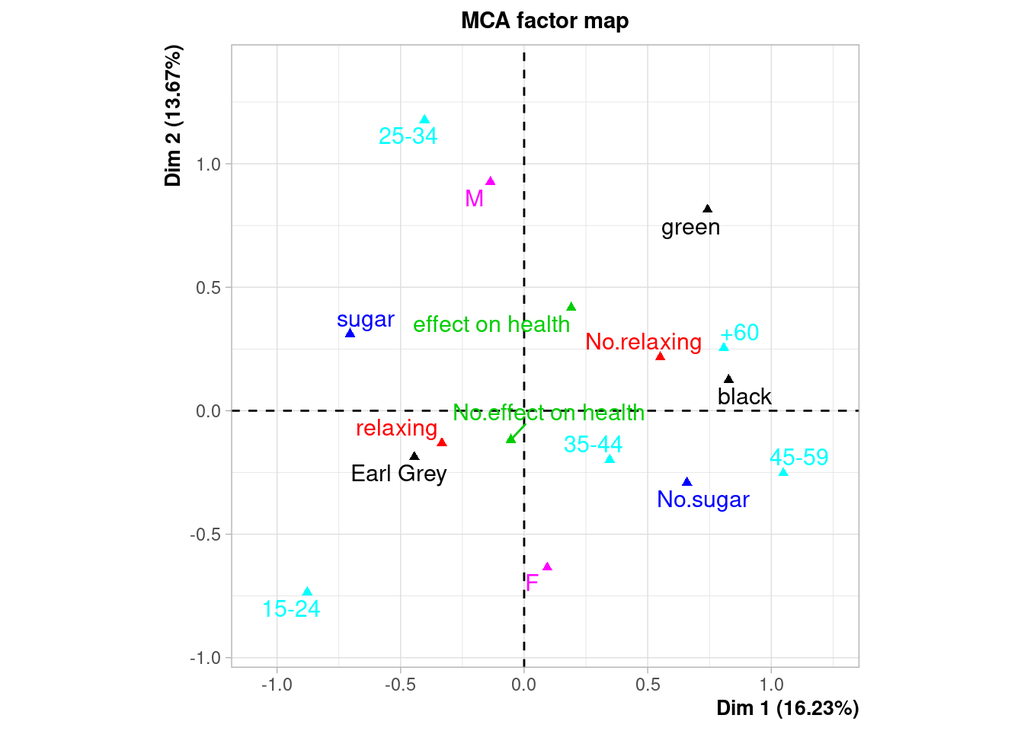

```r
# visualize MCA
plot(mca, invisible=c("ind"), habillage = "quali")
```

This gives a rather nice plot to understand the correlation between young age group (15-24) and Earl Grey tea, which is the most commonly available blend in tea.

Sugar consumption is more common in the lower age groups, as the taste buds are not yet ‘driven in’, so to say.

If designing a set of tea flavors, this graph could give a hint to create product packages and images appealing to the targeted market segments.